# R Notebook

Analysis: Identify Sox2::Oct4 Dimer peaks and track their accessibility and H3k27Ac over time.

# A new bit

So Debbie raised a great point. We expect to see this maintained in iNC at D5 because they have not differentiated yet. So we will compare the signal in this vs the differentiated Sox2 C+R she performed. As a reference we have a 14D Myo Sample in which Sox2 C+R and ATAC-Seq have been performed. Also have H3K27Ac I think.

```
Missing totalTest! totalTest is required for HyperG test.
If totalTest is missing, pvalue will be calculated by estimating
the total binding sites of encoding region of human.
totalTest = humanGenomeSize * (2%(codingDNA) +
             1%(regulationRegion)) / ( 2 * averagePeakWidth )
          = 3.3e+9 * 0.03 / ( 2 * averagePeakWidth)
          = 5e+7 /averagePeakWidth
```

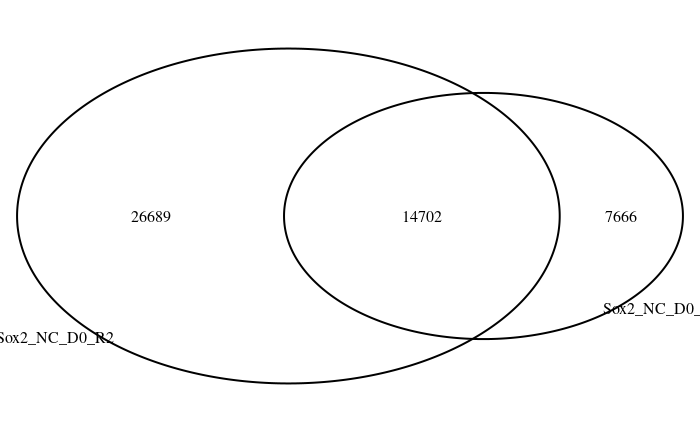

```r
library(rtracklayer)
library(ChIPpeakAnno)

data_dir <- "/data/Austin/workdir/NC_Timecourse_Data/Human_ESC_iNC_CR/"

# Get all Sox2 peaks
Sox2_NC_D0_R1 <- import(con = "/data/Austin/workdir/NC_Timecourse_Data/Human_ESC_iNC_CR/Peaks/H1_std_Sox2hg38_filt.BAM_peaks.narrowPeak")
Sox2_NC_D0_R2 <- import(con = "/data/Austin/workdir/NC_Timecourse_Data/Human_ESC_iNC_CR/Peaks/H1_Sox2_auto_ACAGTG_hg38_filt.BAM_peaks.narrowPeak")
Sox2_NC_D3_R1 <- import(con = "/data/Austin/workdir/NC_Timecourse_Data/Human_ESC_iNC_CR/Peaks/Sox2_NC_day3_R1_gthg38_filt_nodups.BAM_peaks.narrowPeak")
Sox2_NC_D3_R2 <- import(con = "/data/Austin/workdir/NC_Timecourse_Data/Human_ESC_iNC_CR/Peaks/Sox2_NC_day3_R2_gthg38_filt_nodups.BAM_peaks.narrowPeak")
Sox2_NC_D5_R1 <- import(con = "/data/Austin/workdir/NC_Timecourse_Data/Human_ESC_iNC_CR/Peaks/Sox2_gt_NC_1hg38_filt_nodups.BAM_peaks.narrowPeak")
Sox2_NC_D5_R2 <- import(con = "/data/Austin/workdir/NC_Timecourse_Data/Human_ESC_iNC_CR/Peaks/Sox2_gt_NC_2hg38_filt_nodups.BAM_peaks.narrowPeak")
Sox2_Myo_D14_R1 <- import(con = "/data/Austin/workdir/NC_Timecourse_Data/Human_ESC_iNC_CR/Peaks/Sox2_Myo_1hg38_filt_nodups.BAM_peaks.narrowPeak")
Sox2_Myo_D14_R2 <- import(con = "/data/Austin/workdir/NC_Timecourse_Data/Human_ESC_iNC_CR/Peaks/Sox2_Myo_2hg38_filt_nodups.BAM_peaks.narrowPeak")


v1 <- makeVennDiagram(Peaks=list(Sox2_NC_D0_R1,Sox2_NC_D0_R2),
                       NameOfPeaks=c("Sox2_NC_D0_R1","Sox2_NC_D0_R2"))
```

```
Missing totalTest! totalTest is required for HyperG test.
If totalTest is missing, pvalue will be calculated by estimating
the total binding sites of encoding region of human.
totalTest = humanGenomeSize * (2%(codingDNA) +
             1%(regulationRegion)) / ( 2 * averagePeakWidth )
          = 3.3e+9 * 0.03 / ( 2 * averagePeakWidth)
          = 5e+7 /averagePeakWidth
```

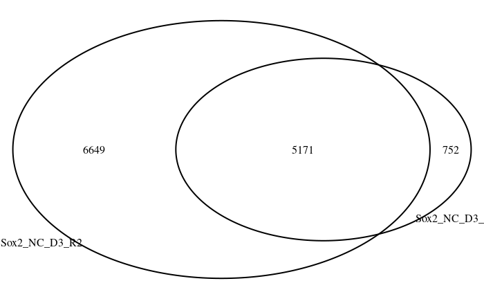

```r
v2 <- makeVennDiagram(Peaks=list(Sox2_NC_D3_R1,Sox2_NC_D3_R2),
                       NameOfPeaks=c("Sox2_NC_D3_R1","Sox2_NC_D3_R2"))
```

```
Missing totalTest! totalTest is required for HyperG test.
If totalTest is missing, pvalue will be calculated by estimating
the total binding sites of encoding region of human.
totalTest = humanGenomeSize * (2%(codingDNA) +
             1%(regulationRegion)) / ( 2 * averagePeakWidth )
          = 3.3e+9 * 0.03 / ( 2 * averagePeakWidth)
          = 5e+7 /averagePeakWidth
```

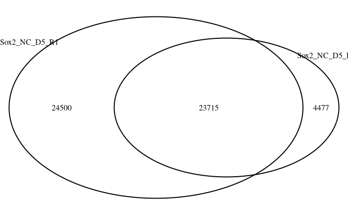

```r
v3 <- makeVennDiagram(Peaks=list(Sox2_NC_D5_R1,Sox2_NC_D5_R2),
                       NameOfPeaks=c("Sox2_NC_D5_R1","Sox2_NC_D5_R2"))
```

```
Missing totalTest! totalTest is required for HyperG test.
If totalTest is missing, pvalue will be calculated by estimating
the total binding sites of encoding region of human.
totalTest = humanGenomeSize * (2%(codingDNA) +
             1%(regulationRegion)) / ( 2 * averagePeakWidth )
          = 3.3e+9 * 0.03 / ( 2 * averagePeakWidth)
          = 5e+7 /averagePeakWidth
```

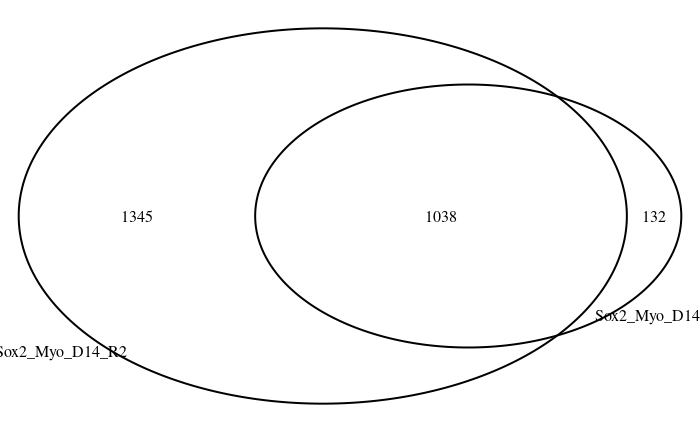

```r
v4 <- makeVennDiagram(Peaks=list(Sox2_Myo_D14_R1,Sox2_Myo_D14_R2),
                       NameOfPeaks=c("Sox2_Myo_D14_R1","Sox2_Myo_D14_R2"))
```

```
Missing totalTest! totalTest is required for HyperG test.
If totalTest is missing, pvalue will be calculated by estimating
the total binding sites of encoding region of human.
totalTest = humanGenomeSize * (2%(codingDNA) +
             1%(regulationRegion)) / ( 2 * averagePeakWidth )
          = 3.3e+9 * 0.03 / ( 2 * averagePeakWidth)
          = 5e+7 /averagePeakWidth
```

```
$p.value
     All_Sox2_Peaks Sox2_Myo_D14_R1 Sox2_Myo_D14_R2 pval
[1,]              0               1               1    0
[2,]              1               0               1    0
[3,]              1               1               0    0

$vennCounts
     All_Sox2_Peaks Sox2_Myo_D14_R1 Sox2_Myo_D14_R2 Counts
[1,]              0               0               0      0
[2,]              0               0               1      0
[3,]              0               1               0      0
[4,]              0               1               1      0
[5,]              1               0               0  83144
[6,]              1               0               1   1297
[7,]              1               1               0    130
[8,]              1               1               1   1012
attr(,"class")
[1] "VennCounts"
```

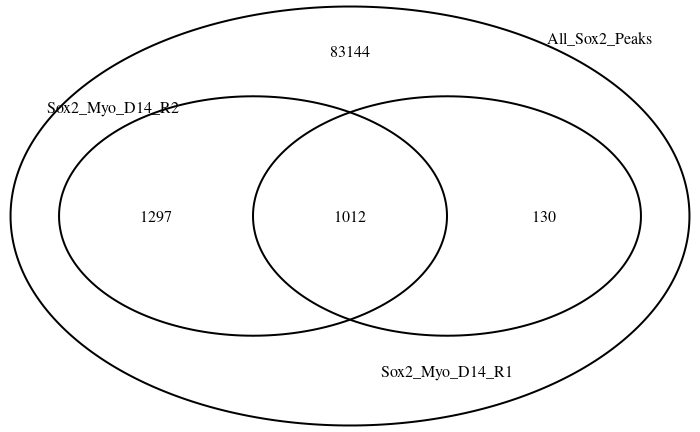

```r
test <- c(Sox2_NC_D0_R1, Sox2_NC_D0_R2)
D0_Sox2_Peaks <- reduce(c(Sox2_NC_D0_R1, Sox2_NC_D0_R2))
D5_Sox2_Peaks <- reduce(c(Sox2_NC_D5_R1, Sox2_NC_D5_R2))
All_Sox2_Peaks <- reduce(c(Sox2_NC_D0_R1, Sox2_NC_D0_R2,
         Sox2_NC_D3_R1, Sox2_NC_D3_R2,
         Sox2_NC_D5_R1, Sox2_NC_D5_R2,
         Sox2_Myo_D14_R1, Sox2_Myo_D14_R2))
# Maybe do top 2k from each set to balance it out more?

makeVennDiagram(Peaks=list(All_Sox2_Peaks, Sox2_Myo_D14_R1,Sox2_Myo_D14_R2),
                       NameOfPeaks=c("All_Sox2_Peaks","Sox2_Myo_D14_R1","Sox2_Myo_D14_R2"))
```

```r
export.bed(object = All_Sox2_Peaks, con = "./Exports/All_Sox2_Peaks.bed")
```

Let’s do a quick differential binding analysis to find Sox2 binding that is specific to ESC and Sox2 binding specific to NC.

```r
library(DiffBind)
Candidate_peaks <- c(D0_Sox2_Peaks, D5_Sox2_Peaks)

Sox2_Signal <- dba.peakset(NULL,peaks=Candidate_peaks,
                      sampID="ESC_D0_1",tissue="ESC",
                      factor="CR",condition="D0",
                      replicate=1,
                      bamReads="/data/Austin/workdir/NC_Timecourse_Data/Human_ESC_iNC_CR/BAM/H1_std_Sox2hg38_filt.bam")

Sox2_Signal <- dba.peakset(Sox2_Signal,peaks=Candidate_peaks,
                      sampID="ESC_D0_2",tissue="ESC",
                      factor="CR",condition="D0",
                      replicate=2,
                      bamReads="/data/Austin/workdir/NC_Timecourse_Data/Human_ESC_iNC_CR/BAM/H1_Sox2_auto_ACAGTG_hg38_filt.bam")

Sox2_Signal <- dba.peakset(Sox2_Signal,peaks=Candidate_peaks,
                      sampID="NC_D5_1",tissue="NC",
                      factor="CR",condition="D5",
                      replicate=1,
                      bamReads="/data/Austin/workdir/NC_Timecourse_Data/Human_ESC_iNC_CR/BAM/Sox2_gt_NC_1hg38_filt_nodups.bam")

Sox2_Signal <- dba.peakset(Sox2_Signal,peaks=Candidate_peaks,
                      sampID="NC_D5_2",tissue="NC",
                      factor="CR",condition="D5",
                      replicate=2,
                      bamReads="/data/Austin/workdir/NC_Timecourse_Data/Human_ESC_iNC_CR/BAM/Sox2_gt_NC_2hg38_filt_nodups.bam")

Sox2_Signal <- dba.count(Sox2_Signal, bParallel = T)
dba.plotPCA(Sox2_Signal, attributes = DBA_CONDITION)
Sox2_Signal <- dba.contrast(Sox2_Signal, contrast = c("Tissue","ESC","NC"))
Sox2_Signal <- dba.analyze(Sox2_Signal)
Sox2_res <- as.data.frame(dba.report(Sox2_Signal))
readr::write_delim(Sox2_res, file = "Exports/Sox2_Differential_ESCvNC.csv", delim = ",",
                   col_names = T)
```

Now annotate these peaks with the number of Oct4::Sox2 JASPAR (MA142.1) binding sites they have.

```r
bedtools coverage -counts -a ./Exports/All_Sox2_Peaks.bed \
-b ./Imports/MA0142.1_TFBS.bed > ./Exports/All_Dimer_Counts.bed
```

Try running motif calling with a lower stringency (p val of 1e-2 vs 1e-4. Okay because 15bp motif)

```bash
fimo --thresh 1e-2 -o MA0142.1.p.1e-2.fimo ~/workdir/diffTF/JASPAR2020_Motifs/MA0142.1.meme /data/Austin/workdir/genome/galGal6/dna/Gallus_gallus.GRCg6a.dna.toplevel.fa
```

```r
suppressPackageStartupMessages(library(readr))
# Read in file
input <- read_tsv(file = "Exports/MA0142.1.p.1e-2.fimo/fimo.tsv", col_names = T, comment = "#")
# Get motifID
id <- as.character(input[1,1])
# Rearrange cols
input <- input[,c(3,4,5,1,7,6)]
# Add chr
input$sequence_name <- paste0("chr", input$sequence_name)
# Remove chr MT, KZ, AADN
input <- input[!grepl(input$sequence_name, pattern = "^chrMT"),]
input <- input[!grepl(input$sequence_name, pattern = "^chrKZ"),]
input <- input[!grepl(input$sequence_name, pattern = "^chrAADN"),]
# Reorder
input <- input[order(input$sequence_name, input$start, input$stop),]

# Write out file
write_delim(input, path = paste0("Exports/MA0142.1.p.1e-2.fimo/",id,"_TFBS.bed"), delim = "\t", col_names = F)
```

Now annotate these peaks with the number of Oct4::Sox2 JASPAR (MA142.1) binding sites they have.

```r
bedtools coverage -counts -a ./Exports/Replicate_Sox2_Peaks.bed \
-b ./Imports/MA0142.1_TFBS.bed > ./Exports/Replicate_Dimer_Counts.bed

bedtools coverage -counts -a ./Exports/All_Sox2_Peaks.bed \
-b ./Imports/MA0142.1_TFBS.bed > ./Exports/All_Dimer_Counts.bed
```

Let’s see how many peaks have a dimer motif. Marginal increase with p val 1e-2 motifs.

```r
All_Dimer_Counts <- read.delim("Exports/All_Dimer_Counts.bed", header = F)
colnames(All_Dimer_Counts) <- c("seqnames","start","stop","strand","c1","strand2","motif_count")
summary(as.factor(All_Dimer_Counts$motif_count))

All_Dimer_Counts.gr <- makeGRangesFromDataFrame(All_Dimer_Counts)
All_Dimer_Counts.gr$motif_count <- All_Dimer_Counts$motif_count

motif_peaks.gr <- All_Dimer_Counts.gr[All_Dimer_Counts.gr$motif_count >= 1]
no_motif_peaks.gr <- All_Dimer_Counts.gr[All_Dimer_Counts.gr$motif_count == 0]

D0_with_motifs <- D0_Sox2_Peaks[overlapsAny(D0_Sox2_Peaks, motif_peaks.gr)]
D5_with_motifs <- D5_Sox2_Peaks[overlapsAny(D5_Sox2_Peaks, motif_peaks.gr)]

v5 <- makeVennDiagram(Peaks = list(D0_with_motifs, D5_with_motifs), NameOfPeaks = c("D0_with_motifs", "D5_with_motifs"))

v5

ESC_Specific_motifs <- D0_with_motifs[!overlapsAny(D0_with_motifs, D5_with_motifs)]
NC_Specific_motifs <- D5_with_motifs[!overlapsAny(D5_with_motifs, D0_with_motifs)]

export.bed(ESC_Specific_motifs, con = "Exports/ESC_Specific_motifs.bed")
export.bed(NC_Specific_motifs, con = "Exports/NC_Specific_motifs.bed")

export.bed(motif_peaks.gr, con = "Exports/Sox2_peaks_with_dualmotif.bed")
export.bed(no_motif_peaks.gr, con = "Exports/Sox2_peaks_with_no_dualmotif.bed")
```

Now let’s quantify the ATAC and H3k27Ac signal at D0,3,5 at these classes of peaks.

```r
library(DiffBind)

H3K27Ac_Signal <- dba.peakset(NULL,peaks=All_Dimer_Counts.gr,
                            sampID="ESC_D0",tissue="ESC",factor="CR",condition="D0",replicate=1, bamReads="/data/Austin/workdir/NC_Timecourse_Data/Human_ESC_iNC_CR/BAM/DB_ES_H3K27ac_2hg38_filt_nodups.bam")

H3K27Ac_Signal <- dba.peakset(H3K27Ac_Signal,peaks=All_Dimer_Counts.gr,
                            sampID="NC_D5_1",tissue="NC",factor="CR",condition="D5",replicate=1, bamReads="/data/Austin/workdir/NC_Timecourse_Data/Human_ESC_iNC_CR/BAM/DB_NC_H3K27ac_1hg38_filt_nodups.bam")

H3K27Ac_Signal <- dba.peakset(H3K27Ac_Signal,peaks=All_Dimer_Counts.gr,
                            sampID="NC_D5_2",tissue="NC",factor="CR",condition="D5",replicate=2, bamReads="/data/Austin/workdir/NC_Timecourse_Data/Human_ESC_iNC_CR/BAM/DB_NC_H3K27ac_2hg38_filt_nodups.bam")

H3K27Ac_Signal

H3K27Ac_Signal <- dba.count(H3K27Ac_Signal, bParallel = T)
dba.plotPCA(H3K27Ac_Signal, attributes = DBA_CONDITION)

# Running DeSeq to get Rlog counts
library(DESeq2)
summarized_experiment2 <- dba(H3K27Ac_Signal, bSummarizedExperiment = T)
summarized_experiment2@assays@data$scores <- summarized_experiment2@assays@data$Reads
#order of counts not correct.
dds_experiment2 <- DESeqDataSet(summarized_experiment2, design = ~ Condition)
dds_experiment2 <- DESeq(dds_experiment2)
dds_results <- results(dds_experiment2)
rld <- rlog(dds_experiment2, blind = FALSE)
# rownames(assay(rld)) <- paste0(H3K27Ac_Signal$peaks[[1]]$Chr,"_",H3K27Ac_Signal$peaks[[1]]$Start,"_",H3K27Ac_Signal$peaks[[1]]$End)
rld_df <- data.frame(row.names = paste0(H3K27Ac_Signal$peaks[[1]]$Chr,"_",H3K27Ac_Signal$peaks[[1]]$Start,"_",H3K27Ac_Signal$peaks[[1]]$End),
           assay(rld))


# Now annotate.
All_Dimer_Counts$PeakID <- paste0(All_Dimer_Counts$seqnames, "_",All_Dimer_Counts$start,"_",All_Dimer_Counts$stop)

rld_df$motif_count <- qdapTools::lookup(rownames(rld_df), All_Dimer_Counts[,c("PeakID","motif_count")])
rld_df$NC_D5_Avg <- rowMeans(rld_df[,c(2,3)])

# Plot the distribution of D0 and D5 Rlog counts of 1,2, and 0 motif occurances.
library(ggplot2)
library(ggpubr)
rld_df_tomelt <- rld_df[,c(1,5)]
rld_df_tomelt$PeakID <- rownames(rld_df_tomelt)
rld_df_melt <- reshape2::melt(rld_df_tomelt)
rld_df_melt$motif_count <- qdapTools::lookup(rld_df_melt$PeakID, All_Dimer_Counts[,c("PeakID","motif_count")])


ggplot(rld_df_melt, aes(x = variable, y = value)) + geom_violin(aes(fill = as.factor(motif_count))) + stat_summary(fun = "median") + facet_grid(. ~ motif_count)


rld_df_melt_nomotifs <- subset(rld_df_melt, rld_df_melt$motif_count == 0)

nomotifs_plot <- ggplot(rld_df_melt_nomotifs, aes(x = variable, y = value)) + geom_violin() + stat_summary(fun = "median") + ylim(c(0,11))
nomotifs_plot + stat_compare_means(method = "t.test")

rld_df_melt_onemotifs <- subset(rld_df_melt, rld_df_melt$motif_count >= 1)

onemotifs_plot <- ggplot(rld_df_melt_onemotifs, aes(x = variable, y = value)) + geom_violin() + stat_summary(fun = "median") + ylim(c(0,11))
onemotifs_plot + stat_compare_means(method = "t.test")

cowplot::plot_grid(nomotifs_plot + stat_compare_means(method = "t.test")
,onemotifs_plot + stat_compare_means(method = "t.test")
,ncol = 2, labels = c("No Motifs", "One+ Motif"))
```

Let’s try with ATAC.

```r
All_Dimer_Counts <- read.delim("Exports/All_Dimer_Counts.bed", header = F)
colnames(All_Dimer_Counts) <- c("seqnames","start","stop","strand","c1","strand2","motif_count")
summary(as.factor(All_Dimer_Counts$motif_count))

All_Dimer_Counts.gr <- makeGRangesFromDataFrame(All_Dimer_Counts)
All_Dimer_Counts.gr$motif_count <- All_Dimer_Counts$motif_count


ATAC_Signal <- dba.peakset(NULL,peaks=All_Dimer_Counts.gr,
                            sampID="ESC_D0_1",tissue="ESC",factor="ATAC",condition="D0",replicate=1, bamReads="/data/Austin/workdir/NC_Timecourse_Data/Human_ESC_ATAC/BAM/ATAC_ES_D0_1_toGRCh38_sorted_nodups.bam")

ATAC_Signal <- dba.peakset(ATAC_Signal,peaks=All_Dimer_Counts.gr,
                            sampID="ESC_D0_2",tissue="ESC",factor="ATAC",condition="D0",replicate=2, bamReads="/data/Austin/workdir/NC_Timecourse_Data/Human_ESC_ATAC/BAM/ATAC_ES_D0_2_toGRCh38_sorted_nodups.bam")

ATAC_Signal <- dba.peakset(ATAC_Signal,peaks=All_Dimer_Counts.gr,
                            sampID="NC_D3_1",tissue="NC",factor="ATAC",condition="D3",replicate=1, bamReads="/data/Austin/workdir/NC_Timecourse_Data/Human_ESC_ATAC/BAM/ATAC_NC_D3_1_toGRCh38_sorted_nodups.bam")

ATAC_Signal <- dba.peakset(ATAC_Signal,peaks=All_Dimer_Counts.gr,
                            sampID="NC_D3_2",tissue="NC",factor="ATAC",condition="D3",replicate=2, bamReads="/data/Austin/workdir/NC_Timecourse_Data/Human_ESC_ATAC/BAM/ATAC_NC_D3_2_toGRCh38_sorted_nodups.bam")

ATAC_Signal <- dba.peakset(ATAC_Signal,peaks=All_Dimer_Counts.gr,
                            sampID="NC_D5_1",tissue="NC",factor="ATAC",condition="D5",replicate=1, bamReads="/data/Austin/workdir/NC_Timecourse_Data/Human_ESC_ATAC/BAM/ATAC_NC_D5_1_toGRCh38_sorted_nodups.bam")

ATAC_Signal <- dba.peakset(ATAC_Signal,peaks=All_Dimer_Counts.gr,
                            sampID="NC_D5_2",tissue="NC",factor="ATAC",condition="D5",replicate=2, bamReads="/data/Austin/workdir/NC_Timecourse_Data/Human_ESC_ATAC/BAM/ATAC_NC_D5_2_toGRCh38_sorted_nodups.bam")

ATAC_Signal <- dba.peakset(ATAC_Signal,peaks=All_Dimer_Counts.gr,
                            sampID="Myo_D14_1",tissue="Myo",factor="ATAC",condition="D14",replicate=1, bamReads="/data/Austin/workdir/NC_Timecourse_Data/Human_ESC_ATAC/BAM/ATAC_Myo_D14_1_toGRCh38_sorted_nodups.bam")

ATAC_Signal <- dba.peakset(ATAC_Signal,peaks=All_Dimer_Counts.gr,
                            sampID="Myo_D14_2",tissue="Myo",factor="ATAC",condition="D14",replicate=2, bamReads="/data/Austin/workdir/NC_Timecourse_Data/Human_ESC_ATAC/BAM/ATAC_Myo_D14_2_toGRCh38_sorted_nodups.bam")

ATAC_Signal <- dba.count(ATAC_Signal, bParallel = T)
ATAC_Signal <- dba.contrast(ATAC_Signal, categories = DBA_CONDITION, minMembers = 2)
ATAC_Signal <- dba.analyze(ATAC_Signal)
dba.plotPCA(ATAC_Signal, attributes = DBA_CONDITION)

# Running DeSeq to get Rlog counts
library(DESeq2)
summarized_experiment2 <- dba(ATAC_Signal, bSummarizedExperiment = T)
summarized_experiment2@assays@data$scores <- summarized_experiment2@assays@data$Reads
#order of counts not correct.
dds_experiment2 <- DESeqDataSet(summarized_experiment2, design = ~ Condition)
dds_experiment2 <- DESeq(dds_experiment2)
dds_results <- results(dds_experiment2)
rld <- rlog(dds_experiment2, blind = FALSE)

rownames(assay(rld)) <- paste0(ATAC_Signal$peaks[[1]]$Chr,"_",ATAC_Signal$peaks[[1]]$Start,"_",ATAC_Signal$peaks[[1]]$End)
rld_df <- data.frame(row.names = paste0(ATAC_Signal$peaks[[1]]$Chr,"_",ATAC_Signal$peaks[[1]]$Start,"_",ATAC_Signal$peaks[[1]]$End),
           assay(rld))


# Now annotate.
All_Dimer_Counts$PeakID <- paste0(All_Dimer_Counts$seqnames, "_",All_Dimer_Counts$start,"_",All_Dimer_Counts$stop)

rld_df$motif_count <- qdapTools::lookup(rownames(rld_df), All_Dimer_Counts[,c("PeakID","motif_count")])
rld_df$NC_D0_Avg <- rowMeans(rld_df[,c(1,2)])
rld_df$NC_D3_Avg <- rowMeans(rld_df[,c(3,4)])
rld_df$NC_D5_Avg <- rowMeans(rld_df[,c(5,6)])
rld_df$NC_D14_Avg <- rowMeans(rld_df[,c(7,8)])

# Plot the distribution of D0 and D5 Rlog counts of 1,2, and 0 motif occurances.
library(ggplot2)
library(ggpubr)
rld_df_tomelt <- rld_df[,c(10,11,12,13)]
rld_df_tomelt$PeakID <- rownames(rld_df_tomelt)

rld_df_melt <- reshape2::melt(rld_df_tomelt)
rld_df_melt$motif_count <- qdapTools::lookup(rld_df_melt$PeakID, All_Dimer_Counts[,c("PeakID","motif_count")])


ggplot(rld_df_melt, aes(x = variable, y = value)) + geom_violin(aes(fill = as.factor(motif_count))) + stat_summary(fun = "median") + facet_grid(. ~ motif_count)


rld_df_melt_nomotifs <- subset(rld_df_melt, rld_df_melt$motif_count == 0)

nomotifs_plot <- ggplot(rld_df_melt_nomotifs, aes(x = variable, y = value)) + geom_violin() + stat_summary(fun = "median") + stat_compare_means()
nomotifs_plot

rld_df_melt_onemotifs <- subset(rld_df_melt, rld_df_melt$motif_count >= 1)

onemotifs_plot <- ggplot(rld_df_melt_onemotifs, aes(x = variable, y = value)) + geom_violin() + stat_summary(fun = "median") + stat_compare_means()
onemotifs_plot


cowplot::plot_grid(nomotifs_plot,onemotifs_plot,ncol = 2, labels = c("No Motifs", "One+ Motif"))

# New plot
# Rlog ATAC counts for D0, D3, and D5 at Dual motifs in hESCs, iNCCs, and no dual motif (all sox2 peaks)

# What ATAC peaks overlap Sox2 CUT&RUN
All_Sox2_Peaks.gr <- import.bed(con = "Exports/All_Sox2_Peaks.bed")
All_Sox2_Peaks.df <- as.data.frame(All_Sox2_Peaks.gr)
All_Sox2_Peaks.df$PeakID <- paste0(All_Sox2_Peaks.df$seqnames, "_", All_Sox2_Peaks.df$start -1 , "_", All_Sox2_Peaks.df$end)

NC_Specific_motifs.gr <- import.bed(con = "Exports/NC_Specific_motifs.bed")
NC_Specific_motifs.df <- as.data.frame(NC_Specific_motifs.gr)
NC_Specific_motifs.df$PeakID <- paste0(NC_Specific_motifs.df$seqnames, "_", NC_Specific_motifs.df$start -1 , "_", NC_Specific_motifs.df$end)

ESC_Specific_motifs.gr <- import.bed(con = "Exports/ESC_Specific_motifs.bed")
ESC_Specific_motifs.df <- as.data.frame(ESC_Specific_motifs.gr)
ESC_Specific_motifs.df$PeakID <- paste0(ESC_Specific_motifs.df$seqnames, "_", ESC_Specific_motifs.df$start -1 , "_", ESC_Specific_motifs.df$end)


rld_df_melt$motif2 <- ifelse(rld_df_melt$PeakID %in% ESC_Specific_motifs.df$PeakID, "DualMotif_hESC",
       ifelse(rld_df_melt$PeakID %in% NC_Specific_motifs.df$PeakID, "DualMotif_hiNCCs", "No_DualMotif"))

rld_df_melt$motif2 <- as.factor(rld_df_melt$motif2)

subset_rld <- rld_df_melt[rld_df_melt$variable %in% c("NC_D0_Avg",
                                                      "NC_D3_Avg",
                                                      "NC_D5_Avg"),]

subset_rld$Comparison <- paste0(subset_rld$variable, "_", subset_rld$motif2)

symnum.args <- list(cutpoints = c(0, 0.0001, 0.001, 0.01, 0.05, 1), symbols = c("****", "***", "**", "*", "ns"))

ggplot(subset_rld, aes(x = motif2, y = value, color = variable, group = Comparison)) + geom_boxplot(outlier.alpha = 0.8)

ggsave(filename = "Exports/Enriched_Motifs_Over_Time.eps")
# Individual one-sided t-tests for the following groups
# D0 DualMotif_hESCs vs D5 DualMotif_hESCs
t.test(x = subset_rld[subset_rld$Comparison == "NC_D0_Avg_DualMotif_hESC",3],
       y = subset_rld[subset_rld$Comparison == "NC_D5_Avg_DualMotif_hESC",3],
       alternative = "greater")
# p-value = 0.002831

# D0 DualMotif_hiNCCs vs D5 DualMotif_hiNCCs
t.test(x = subset_rld[subset_rld$Comparison == "NC_D0_Avg_DualMotif_hiNCCs",3],
       y = subset_rld[subset_rld$Comparison == "NC_D5_Avg_DualMotif_hiNCCs",3],
       alternative = "less")
# p-value = 0.000122

stat_compare_means(method = "t.test", symnum.args = symnum.args,comparisons = list(c("NC_D0_Avg_DualMotif_hESC", "NC_D5_Avg_DualMotif_hESC")))
```

```r
# Let's see the Sox2 signal at Sox2 peaks with or without the motif at d0, d3, d5

cd /data/Austin/workdir/NC_Timecourse_Data/Human_ESC_iNC_CR/BW

computeMatrix reference-point -S  H1_Sox2_auto_ACAGTG_hg38_filt.BAM.bw Sox2_NC_day3_R2_gthg38_filt_nodups.BAM.bw Sox2_gt_NC_2hg38_filt_nodups.BAM.bw -R ~/local_git/NC_Timecourse/CR/Human_ESC_iNC/Exports/Sox2_peaks_with_dualmotif.bed ~/local_git/NC_Timecourse/CR/Human_ESC_iNC/Exports/Sox2_peaks_with_no_dualmotif.bed -b 1000 -a 1000 -bs 10 -o ~/local_git/NC_Timecourse/CR/Human_ESC_iNC/Exports/Sox2_CR_dual_vs_no_motif_2.mat.gz --missingDataAsZero --referencePoint center --numberOfProcessors 62

plotProfile -m ~/local_git/NC_Timecourse/CR/Human_ESC_iNC/Exports/Sox2_CR_dual_vs_no_motif.mat.gz -out ~/local_git/NC_Timecourse/CR/Human_ESC_iNC/Exports/Sox2_CR_dual_vs_no_motif.eps --plotType heatmap --dpi 600

gs -dSAFER -dEPSCrop -r300 -sDEVICE=pngalpha -o ~/local_git/NC_Timecourse/CR/Human_ESC_iNC/Exports/Sox2_CR_dual_vs_no_motif.png ~/local_git/NC_Timecourse/CR/Human_ESC_iNC/Exports/Sox2_CR_dual_vs_no_motif.eps

plotHeatmap -m ~/local_git/NC_Timecourse/CR/Human_ESC_iNC/Exports/Sox2_CR_dual_vs_no_motif.mat.gz -out ~/local_git/NC_Timecourse/CR/Human_ESC_iNC/Exports/Sox2_CR_dual_vs_no_motif_heatmap.eps --plotType lines --dpi 600

gs -dSAFER -dEPSCrop -r300 -sDEVICE=pngalpha -o  ~/local_git/NC_Timecourse/CR/Human_ESC_iNC/Exports/Sox2_CR_dual_vs_no_motif_heatmap.png ~/local_git/NC_Timecourse/CR/Human_ESC_iNC/Exports/Sox2_CR_dual_vs_no_motif_heatmap.eps
```

```r
# Let's see the ATAC signal at ESC or NC specific peaks with the dimer motif.

cd /data/Austin/workdir/NC_Timecourse_Data/Human_ESC_ATAC/BW

computeMatrix reference-point -S  ATAC_ES_D0_1_toGRCh38_sorted_nodups.bw ATAC_NC_D3_1_toGRCh38_sorted_nodups.bw ATAC_NC_D5_2_toGRCh38_sorted_nodups.bw -R ~/local_git/NC_Timecourse/CR/Human_ESC_iNC/Exports/ESC_Specific_motifs.bed ~/local_git/NC_Timecourse/CR/Human_ESC_iNC/Exports/NC_Specific_motifs.bed -b 1000 -a 1000 -bs 10 -o ~/local_git/NC_Timecourse/CR/Human_ESC_iNC/Exports/ESC_vs_NC_withmotif.mat.gz --missingDataAsZero --referencePoint center --numberOfProcessors 62

plotProfile -m ~/local_git/NC_Timecourse/CR/Human_ESC_iNC/Exports/ESC_vs_NC_withmotif.mat.gz -out ~/local_git/NC_Timecourse/CR/Human_ESC_iNC/Exports/ESC_vs_NC_withmotif_profile.eps --plotType heatmap --dpi 600

gs -dSAFER -dEPSCrop -r300 -sDEVICE=pngalpha -o ~/local_git/NC_Timecourse/CR/Human_ESC_iNC/Exports/ESC_vs_NC_withmotif_profile.png ~/local_git/NC_Timecourse/CR/Human_ESC_iNC/Exports/ESC_vs_NC_withmotif_profile.eps

plotHeatmap -m ~/local_git/NC_Timecourse/CR/Human_ESC_iNC/Exports/ESC_vs_NC_withmotif.mat.gz -out ~/local_git/NC_Timecourse/CR/Human_ESC_iNC/Exports/ESC_vs_NC_withmotif_heatmap.eps --plotType lines --dpi 600

gs -dSAFER -dEPSCrop -r300 -sDEVICE=pngalpha -o  ~/local_git/NC_Timecourse/CR/Human_ESC_iNC/Exports/ESC_vs_NC_withmotif_heatmap.png ~/local_git/NC_Timecourse/CR/Human_ESC_iNC/Exports/ESC_vs_NC_withmotif_heatmap.eps
```

```r
library(rtracklayer)
library(ChIPseeker)
library(TxDb.Hsapiens.UCSC.hg38.knownGene)
library(org.Hs.eg.db)

ESC_Specific_motifs <- import.bed("Exports/ESC_Specific_motifs.bed")
NC_Specific_motifs <- import.bed("Exports/NC_Specific_motifs.bed")

ESC_Specific_motifs_anno <- annotatePeak(ESC_Specific_motifs,
                                         TxDb = TxDb.Hsapiens.UCSC.hg38.knownGene,
                                         annoDb = "org.Hs.eg.db")
ESC_Specific_motifs_anno <- as.data.frame(ESC_Specific_motifs_anno)

NC_Specific_motifs_anno <- annotatePeak(NC_Specific_motifs,
                                         TxDb = TxDb.Hsapiens.UCSC.hg38.knownGene,
                                         annoDb = "org.Hs.eg.db")
NC_Specific_motifs_anno <- as.data.frame(NC_Specific_motifs_anno)
```

```r
library(DiffBind)

# TFAP2A Overexpression induction
Sox2_Signal_OE <- dba.peakset(NULL,peaks="/data/Austin/workdir/NC_Timecourse_Data/H1_TFAP2A_OE2_SOX2-CR/Peaks/12793_10099_147164_HGHM3BGXK_H1_GFP_Sox2_1_AGTTCCGT_R1_toGRCh38_nodups.bam_peaks.narrowPeak", peak.format = "narrow",
                      sampID="ESC_D5_GFP_OE_1",tissue="ESC",
                      factor="GFP",condition="D5",
                      replicate=2,
                      bamReads="/data/Austin/workdir/NC_Timecourse_Data/H1_TFAP2A_OE2_SOX2-CR/BAM/12793_10099_147164_HGHM3BGXK_H1_GFP_Sox2_1_AGTTCCGT_R1_toGRCh38_nodups.bam")

Sox2_Signal_OE <- dba.peakset(Sox2_Signal_OE,peaks="/data/Austin/workdir/NC_Timecourse_Data/H1_TFAP2A_OE2_SOX2-CR/Peaks/12793_10099_147165_HGHM3BGXK_H1_GFP_Sox2_2_ATGTCAGA_R1_toGRCh38_nodups.bam_peaks.narrowPeak", peak.format = "narrow",
                      sampID="ESC_D5_GFP_OE_2",tissue="ESC",
                      factor="GFP",condition="D5",
                      replicate=2,
                      bamReads="/data/Austin/workdir/NC_Timecourse_Data/H1_TFAP2A_OE2_SOX2-CR/BAM/12793_10099_147165_HGHM3BGXK_H1_GFP_Sox2_2_ATGTCAGA_R1_toGRCh38_nodups.bam")

Sox2_Signal_OE <- dba.peakset(Sox2_Signal_OE,peaks="/data/Austin/workdir/NC_Timecourse_Data/H1_TFAP2A_OE2_SOX2-CR/Peaks/12793_10099_147166_HGHM3BGXK_H1_hTFAP2A_Sox2_1_CCGTCCGC_R1_toGRCh38_nodups.bam_peaks.narrowPeak", peak.format = "narrow",
                      sampID="ESC_D5_TFAP2A_OE_1",tissue="NC",
                      factor="TFAP2A",condition="D5",
                      replicate=1,
                      bamReads="/data/Austin/workdir/NC_Timecourse_Data/H1_TFAP2A_OE2_SOX2-CR/BAM/12793_10099_147166_HGHM3BGXK_H1_hTFAP2A_Sox2_1_CCGTCCGC_R1_toGRCh38_nodups.bam")

Sox2_Signal_OE <- dba.peakset(Sox2_Signal_OE,peaks="/data/Austin/workdir/NC_Timecourse_Data/H1_TFAP2A_OE2_SOX2-CR/Peaks/12793_10099_147167_HGHM3BGXK_H1_hTFAP2A_Sox2_2_GTAGAGAT_R1_toGRCh38_nodups.bam_peaks.narrowPeak", peak.format = "narrow",
                      sampID="ESC_D5_TFAP2A_OE_2",tissue="NC",
                      factor="TFAP2A",condition="D5",
                      replicate=2,
                      bamReads="/data/Austin/workdir/NC_Timecourse_Data/H1_TFAP2A_OE2_SOX2-CR/BAM/12793_10099_147167_HGHM3BGXK_H1_hTFAP2A_Sox2_2_GTAGAGAT_R1_toGRCh38_nodups.bam")


Sox2_Signal_OE <- dba.count(Sox2_Signal_OE, bParallel = T, summits = F)
dba.plotPCA(Sox2_Signal_OE, attributes = c(DBA_CONDITION, DBA_FACTOR))
Sox2_Signal_OE <- dba.contrast(Sox2_Signal_OE, contrast = c("Factor","TFAP2A","GFP"))
Sox2_Signal_OE <- dba.analyze(Sox2_Signal_OE)
All_Sox2 <- as.data.frame(dba.report(Sox2_Signal_OE, th = 1))
Sox2_res <- as.data.frame(dba.report(Sox2_Signal_OE, bUsePval = F, th = 0.05))
TFAP2A_OE_SOX2 <- Sox2_res[Sox2_res$Fold>0,]
GFP_OE_SOX2 <- Sox2_res[Sox2_res$Fold<0,]

TFAP2A_OE_SOX2$PeakID <- paste0(TFAP2A_OE_SOX2$seqnames,"_",TFAP2A_OE_SOX2$start, "_",TFAP2A_OE_SOX2$end)
TFAP2A_OE_SOX2$strand <- "+"

write_tsv(TFAP2A_OE_SOX2[,c("seqnames","start","end","PeakID","Fold","strand")],
          file = "Exports/Sox2_peaks_enrichedinTFAP2AOE.bed",
          col_names = F)

# Let's make a volcano plot for fun.
# We could scan the top hits and label those that have the dimer motif!

Sox2_Labeled <- All_Sox2 %>% mutate(threshold = ifelse(Fold > 0.5 & FDR < 0.01, "A", ifelse(Fold < -0.5 & FDR < 0.01, "B", "C")))

# test homer round 2 with selective cutoff.
TFAP2A_OE_SOX2_Selective <- Sox2_Labeled[Sox2_Labeled$threshold == "A",]
TFAP2A_OE_SOX2_Selective$PeakID <- paste0(TFAP2A_OE_SOX2_Selective$seqnames,"_",TFAP2A_OE_SOX2_Selective$start, "_",TFAP2A_OE_SOX2_Selective$end)
TFAP2A_OE_SOX2_Selective$strand <- "+"

write_tsv(TFAP2A_OE_SOX2_Selective[,c("seqnames","start","end","PeakID","Fold","strand")],
          file = "Exports/Selective_Sox2_peaks_enrichedinTFAP2AOE.bed",
          col_names = F)
TFAP2A_OE_SOX2_Selective.gr <- makeGRangesFromDataFrame(TFAP2A_OE_SOX2_Selective)

g <- ggplot(data = Sox2_Labeled, aes(x = Fold, y = -log10(FDR))) +
        geom_point(aes(color = threshold), size = 1, alpha = 1) +
        scale_color_manual(values = c("A" = "#e45649", "B" = "#0584bc", "C" = "#d3d2d6")) +
        ggtitle("SOX2 C&R Analysis") +
        theme_classic() +
        xlab("Log2 Fold Change") +
        ylab(paste0("-Log10 Adj. p value")) +
        theme(legend.position = "none")
g


ggsave(filename = paste0("./Exports/TFAP2A_OE2_SOX2_CR_Volcano_labeled.png"), plot = g, width = 4, height = 4, device = "png")

ggsave(filename = paste0("./Exports/TFAP2A_OE2_SOX2_CR_Volcano_labeled.pdf"), plot = g, width = 4, height = 4, device = "pdf")
```

```bash
bedtools getfasta -fi /data/Austin/workdir/genome/hg38/dna/hg38.fa -bed Selective_Sox2_peaks_enrichedinTFAP2AOE.bed -fo Selective_Sox2_peaks_enrichedinTFAP2AOE.fa
fimo --thresh 1e-2 -o Dimer_in_Selective_Sox2_peaks ~/local_git/NC_Timecourse/CR/Human_ESC_iNC/Imports/MA0142.1.meme Selective_Sox2_peaks_enrichedinTFAP2AOE.fa
```

Recreate volcano with labeling.

[figure not shown]

```r
g2
ggsave(filename = paste0("./Exports/TFAP2A_OE2_SOX2_CR_Volcano_Dimer.png") width = 4, height = 4, device = "png")
```

```
Error: unexpected symbol in "ggsave(filename = paste0("./Exports/TFAP2A_OE2_SOX2_CR_Volcano_Dimer.png") width"
```

```bash
# Peaks that increase in SOX2 binding upon TFAP2A Overexpression
findMotifsGenome.pl Sox2_peaks_enrichedinTFAP2AOE.bed /data/Austin/workdir/genome/hg38/dna/hg38.fa TFAP2AOE_Enriched_SOX2CR -p 32

# Selective Peaks that increase in SOX2 binding upon TFAP2A Overexpression
findMotifsGenome.pl Selective_Sox2_peaks_enrichedinTFAP2AOE.bed /data/Austin/workdir/genome/hg38/dna/hg38.fa Selective_TFAP2AOE_Enriched_SOX2CR -p 62

# All SOX2 peaks captured from previous CR's
findMotifsGenome.pl Replicate_Sox2_Peaks.bed /data/Austin/workdir/genome/hg38/dna/hg38.fa Background_SOX2CR -p 32
```

Let’s look at peaks

Look at All Sox2 peaks vs ESC dimer locations vs NC dimer locations in regular SOX2 CUT&RUN and OE

```bash
computeMatrix reference-point -S  ATAC_ES_D0_1_toGRCh38_sorted_nodups.bw ATAC_NC_D3_1_toGRCh38_sorted_nodups.bw ATAC_NC_D5_2_toGRCh38_sorted_nodups.bw -R ~/local_git/NC_Timecourse/CR/Human_ESC_iNC/Exports/ESC_Specific_motifs.bed ~/local_git/NC_Timecourse/CR/Human_ESC_iNC/Exports/NC_Specific_motifs.bed -b 1000 -a 1000 -bs 10 -o ~/local_git/NC_Timecourse/CR/Human_ESC_iNC/Exports/ESC_vs_NC_withmotif.mat.gz --missingDataAsZero --referencePoint center --numberOfProcessors 62

plotProfile -m ~/local_git/NC_Timecourse/CR/Human_ESC_iNC/Exports/ESC_vs_NC_withmotif.mat.gz -out ~/local_git/NC_Timecourse/CR/Human_ESC_iNC/Exports/ESC_vs_NC_withmotif_profile.eps --plotType heatmap --dpi 600
```